# Coursework Report

*N* removed NAs: 2

*N* removed typo: 1

*N* removed <18: 26

*N* total clean: 122

| Group | *N* | *M*<sub>age</sub> | *M*<sub>rating</sub> |
| --- | --- | --- | --- |
| Control | 57 | 20.54 | 6.08 |
| Experim | 65 | 20.80 | 5.37 |

**Main analysis results**

*t*(120) = 5.03, *p* < .001

[interactive chart not shown]

[figure not shown]

[interactive chart not shown]

# Coursework Report

Analysing Data, Spring 2020

# Methods

## Participants

```
## # A tibble: 2 x 4
##   group            n mean_years sd_years
##   <fct>        <int>      <dbl>    <dbl>
## 1 control         57       20.5     1.85
## 2 experimental    65       20.8     2.06
```

## Design

Does colour influence attractiveness in men? This question is the conceptual hypothesis. The independant variables in this study where the colour condition groups (whether the person was shown an image of a man with white or red frame). The colour of frame shown to participants was the predictor, and the attractiveness rating that each person gave was the continuous variable (dependant variable). The attractivness rating that was analysed was composed of an average rating from 1-9 (1 being the least attractive, and 9 being the most attractive) on three questsions: How attractive do you find this person?, How pleasent do you find this person? and how likly are you to find this person attractive in person? The higher the avergae attractiveness rating, the more attractive the participant found he image. The operational hypothesis is as follows: Does viewing a different colour frame around an image of a moderatly attractive man influence the mean ratings of his attractivness? This was analysed using a t-test to exmaine the differnce of the means of attractivness of both colour groups.

# Results

The mean attractiveness rating of the control group is higher than the mean attractiness rating of the experimetal group. Below is a table of results, including the composite attractiveness ratings.

```
##     id_code             group        years           item_1          item_2          item_3
##  ADBM   :  1   control     :57   Min.   :18.00   Min.   :2.000   Min.   :3.000   Min.   :3.000
##  AQWR   :  1   experimental:65   1st Qu.:19.00   1st Qu.:5.000   1st Qu.:5.000   1st Qu.:5.000
##  AWBH   :  1                     Median :21.00   Median :6.000   Median :6.000   Median :6.000
##  AXNA   :  1                     Mean   :20.68   Mean   :5.631   Mean   :5.566   Mean   :5.918
##  BEPI   :  1                     3rd Qu.:22.00   3rd Qu.:6.000   3rd Qu.:6.000   3rd Qu.:7.000
##  BPIM   :  1                     Max.   :26.00   Max.   :9.000   Max.   :9.000   Max.   :9.000
##  (Other):116
##   opinion_comp
##  Min.   :3.667
##  1st Qu.:5.000
##  Median :5.667
##  Mean   :5.705
##  3rd Qu.:6.333
##  Max.   :7.667
##
```

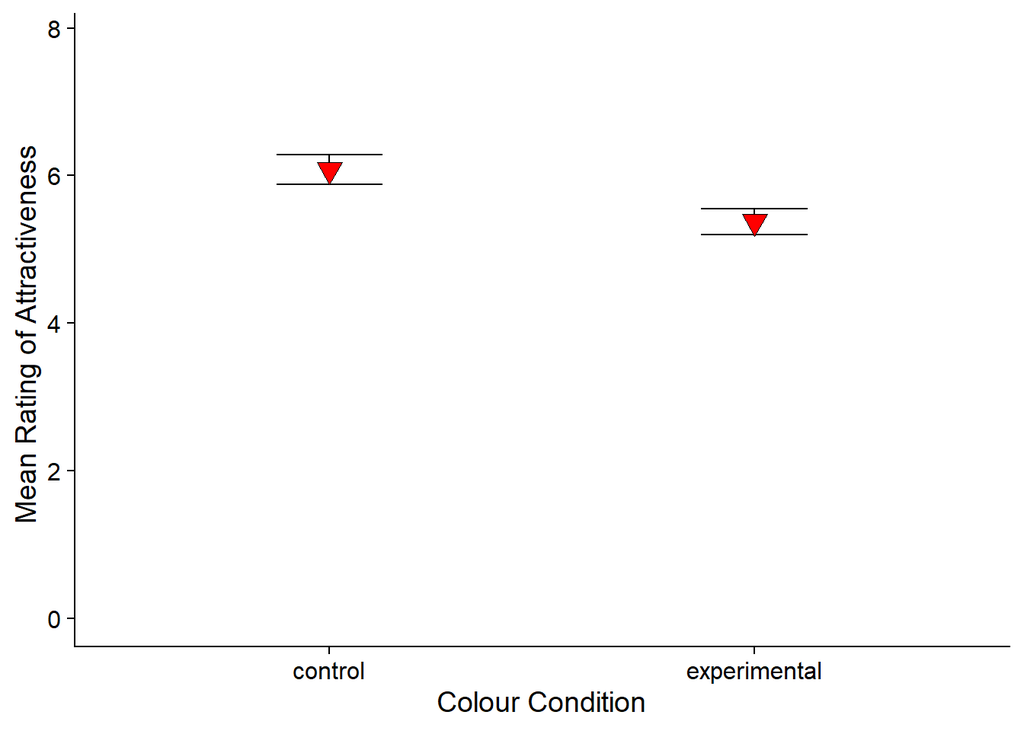

As can be seen from the graph above, the mean rating of attractivness of the control group (white frame) is higher than the experimental group(red frame). Therefore, we an conclude that coloured frames have a negative effect on attractivness when viewing images of men.

# Discussion

The above results show that women have on averge rated images of men with white frames as more attractive than images of men with a red frame.

My results compared to other studies, such as that on investiagting chromatic and anchromatic colours effect on attractivness (Axelsson, 2007), also show contrasting results (women found men with chromatic colours to be more attractive). This could mean that the effect I was testing may have had contrasting reults due to the particular shade red being used, or prehaps the usage of red being in a frame and not in the image itslef (as the other studies did) .This could have caused this differnce in result.

Strengths to this study include that the indepenant measures desgin used did not have any negative carry over effects to other conditions.

Based on the research of the original study, that shows a positive correleation between the colour red and having a higher status,I believe a limitation to my study would be that the direct status of the women in the study was not taken. The evidence behind the attractivness to the colour red in men (due to red linking to having a higher status) is known to be prevelant due to women generally finding it harder to strive in a workplace, so they look to gain social a higher status in thier marital partner (Buller, 2005). Therefore, given this information, it would be correct to assume that women that already consider themselves at a high status may not find men in a red frame as attractive (for example women that are already in a high position at thier workplace). Given this, not having the status of the women in my study does not allow for the results to be generalised to all women of varing status.

Does red really make men more attractive? I can conclude that if the sample group has the correct qualities that correspond with what may make women find red more attractive on men (for example, ovulation stage and the status of women) then, a positive correlation between attractiveness and the colour red may be reliable. However, given the lack of generalisiablity in this study and in previous studies, as they do not record the diffrent qualitites that may change womens perception of attractiveness, the results of these studies cannot be generalised to suit all women.

For future research, I would suggest testing womens attractivness rating on men displaying the colur red from various social statuses. For example, having groups of women that are from a high social status to low social status. Analysing the differing results from these groups, may help to confirm or deny the research into the colour red being linked to having a high status, and that being what contributes to why women find the red images of men attractive.

Another future study that may help to increasse the generalisabilty of the study, is having women state their ovulation stage, and grouping women in accord to thier stages. This may allow for some explanation as to why some groups of women show not to be as attractd to men displaying red (e.g this current study) and why other do (Elliots, 2010)

My main findings where that the results from my study do not correspond with previous studies. I have concluded that this may be due to the varying characteristics of the women used this study and that of those on other studies.

# References

Elliot, A., Niesta Kayser, D., Greitemeyer, T., Lichtenfeld, S., Gramzow, R., Maier, M., & Liu, H. (2010). Red, rank, and romance in women viewing men. Journal Of Experimental Psychology: General, 139(3), 399-417

Penton-Voak, I., Perrett, D., Castles, D., Kobayashi, T., Burt, D., Murray, L., & Minamisawa, R. (1999). Menstrual cycle alters face preference. Nature, 399(6738), 741-742.

Simpson, J., & Gangestad, S. (1992). Sociosexuality and Romantic Partner Choice. Journal Of Personality, 60(1), 31-51.

Buston, P., & Emlen, S. (2003). Cognitive processes underlying human mate choice: The relationship between self-perception and mate preference in Western society. Proceedings Of The National Academy Of Sciences, 100(15), 8805-8810.

Seong, H., & Yi, K. (2016). Wearing Condition & Preference of Shirts for Males in Their Twenties and Thirties. Fashion Business, 20(5), 60-75.